# 02_prueba_obs_nopress

Pao

8/15/2019

## Asimilación de observaciones sin presión en la estación.

Hice una prueba de asimilación (variación, solo GSI) con las siguientes observaciones:

| lat | lon | elev | estación | fecha | temp | humead | u | v | press |
| --- | --- | --- | --- | --- | --- | --- | --- | --- | --- |
| -30.87 | -63.85 | 65.153 | TEST | 20181120210000 | 33.397 | 0.00795423 | -1.41525 | -4.72159 | 100000000000 |
| -31.00 | -64.00 | 65.153 | TEST | 20181120210000 | 33.397 | 0.00795423 | -1.41525 | -4.72159 | 100000 |

La primera es un registro sin observación de presión en la estación (1e11 corresponde a NA) y es codificado en el prepBUFR como 187 (para t y q) o 287 (para u y v). El segundo registro es igual pero en este caso tiene la obvservación de presión (1000 hPa) y se codifica como 181 y 281 respectivamente.

Se cambió la configuracón de GSI para que permita la asimilación de observaciones tipo 187 y 287 (usage = 1 en el archivo convinfo) y la tabla de errores correspondiente (archivo errtable).

### Diag files

En el archivo diag generado se ve lo siguiente:

| var | stationID | type | dhr | lat | lon | pressure | usage.flag | obs | obs.guess | obs2 | obs.guess2 | rerr |
| --- | --- | --- | --- | --- | --- | --- | --- | --- | --- | --- | --- | --- |
| ps | TEST | 181 | 0 | -31.00 | 296.00 | 1.00e+03 | 1 | 1.00e+03 | -6.42e-02 | 1.00e+10 | 0.00e+00 | 1.94e+00 |
| t | TEST | 181 | 0 | -31.00 | 296.00 | 1.00e+03 | 1 | 3.07e+02 | 2.19e+00 | 1.00e+10 | 0.00e+00 | 1.00e+10 |
| q | TEST | 181 | 0 | -31.00 | 296.00 | 1.00e+03 | 1 | 7.95e-03 | -4.18e-04 | 3.00e-02 | 1.00e+10 | 1.91e-02 |
| uv | TEST | 281 | 0 | -31.00 | 296.00 | 9.57e+02 | 1 | -1.40e+00 | 3.58e+00 | -4.70e+00 | 2.77e+00 | 1.00e+09 |
| ps | TEST | 187 | 0 | -30.87 | 296.15 | 1.00e+11 | -1 | -1.00e+05 | -1.00e+05 | 1.00e+10 | 1.00e+10 | Inf |
| t | TEST | 187 | 0 | -30.87 | 296.15 | 1.00e+11 | 1 | 3.07e+02 | 1.11e+00 | 1.00e+10 | 1.00e+10 | 1.00e+10 |
| q | TEST | 187 | 0 | -30.87 | 296.15 | 1.00e+11 | 1 | 7.95e-03 | -2.98e-04 | 3.15e-02 | 1.00e+10 | 3.24e+07 |
| uv | TEST | 287 | 0 | -30.87 | 296.15 | 9.70e+02 | 1 | -1.40e+00 | 3.07e+00 | -4.70e+00 | 2.03e+00 | 1.00e+09 |

Me surgen las siguientes dudas:

### fit_xxx files

Los archivos fit_xxx contienen información resumen sobre las observaciones (cuantas se asimilan y rechazan por tipo y nivel, el bias, rms, etc.). En el caso de la temperatura solo cuenta 1 observación asimilada tipo 181 sin noticias de la observación 187. Sin embargo al revisar la cantidad de observaciones leidas dice 2, y también dice que se queda con 2. Esto me ahace pensar que los archivos fit de temperatura no están preparados para guardar información de observaciones que normalmente no se asimilan.

Lo mismo ocurre con el fit asociado a la humedad. Por suerte el fit de la presión muestra lo esperado (una obs asimilada tipo 181 y una obs rechazada tipo 187). El fit del viento muestra ambas observaciones (181 y 187) y supuestamente las asimila a las dos!

### Analisis y guess

Veamos como se modifican los campos de las variables. Primero lo primero: debería haber asimilado solo el registro 187/287 para poder medir el impacto asociado solo a ese tipo de observación.

Lo más notorio es que el impacto parece generarse en todo el dominio.

> Revisar escalas de localización

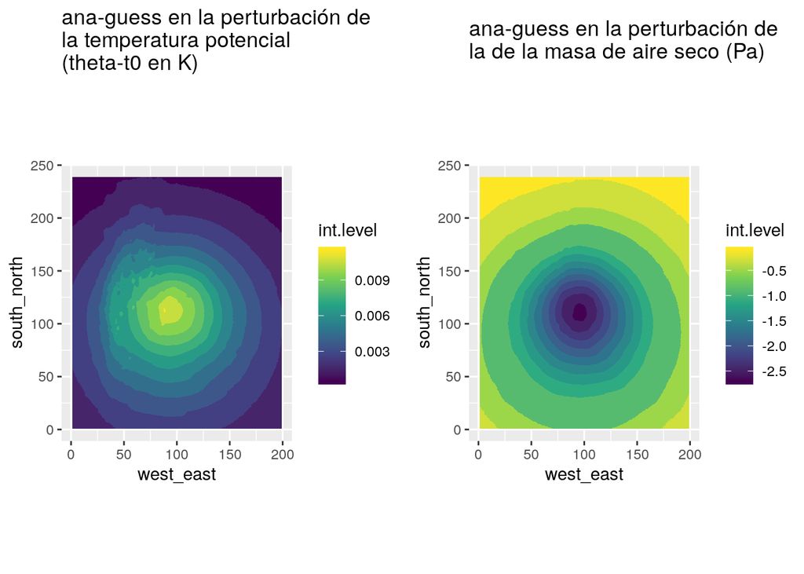

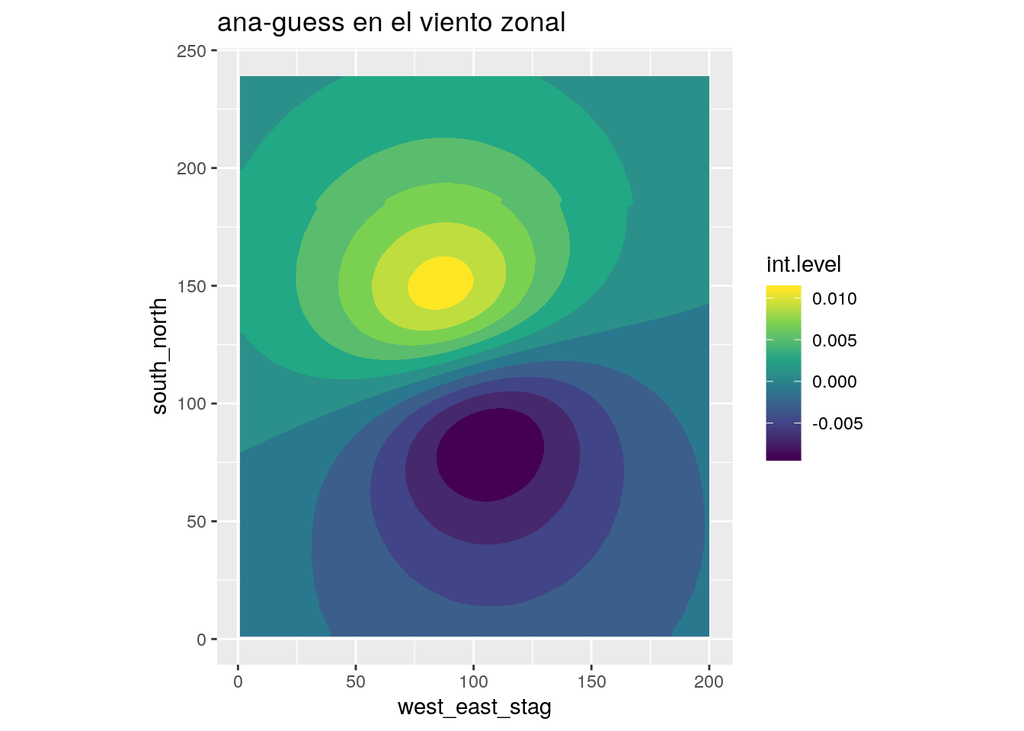

### Asimilación con un único registro 187/287

No hay diferencia en el analisis porque pareciera que no asimila nada. Lo fit muestran que lee observaciones y “se las queda” pero no hay estadística. En el caso del diag las marca para usar pero parece que luego cambia de idea.

Por la asimetría que se ve en la diferencia entre el analisis y el guess en la perturbación de la temperatura, me animo a decir que se asimilaron las observaciones 187 y 287 pero es raro que al asimilar solo esas, no da nada.

### Comparación Ana-Guess incorporando observaciones sin presión.

#### Temperatura (type = 187)

Observación:

- Ubicación: -34.82 ; 301.47
- Valor: 0.302E+03
- Diff: -0.121E+00
- Error: 0.150E+01

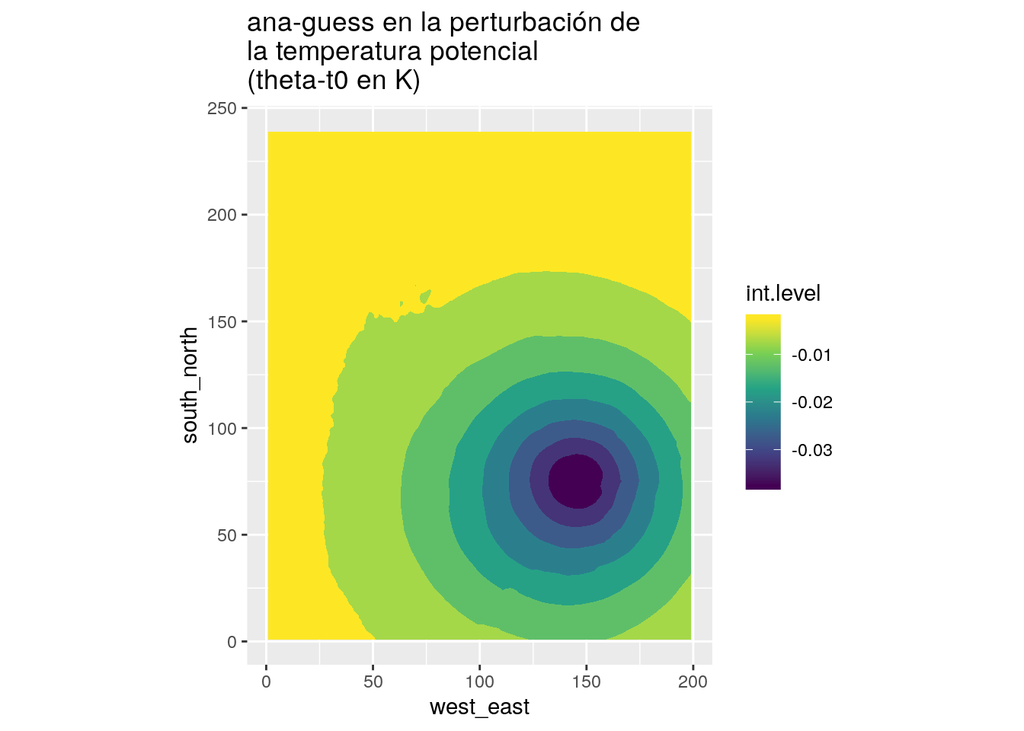

```r
model[bottom_top == 1] %>%
  dcast(bottom_top + south_north + west_east ~ model, value.var = "T") %>%
  ggplot(aes(west_east, south_north)) +
  geom_contour_fill(aes(z = (ana187_t - guess))) +
  scale_fill_viridis_c() +
  coord_fixed() +
  labs(title = "ana-guess en la perturbación de \nla temperatura potencial \n(theta-t0 en K)")
```

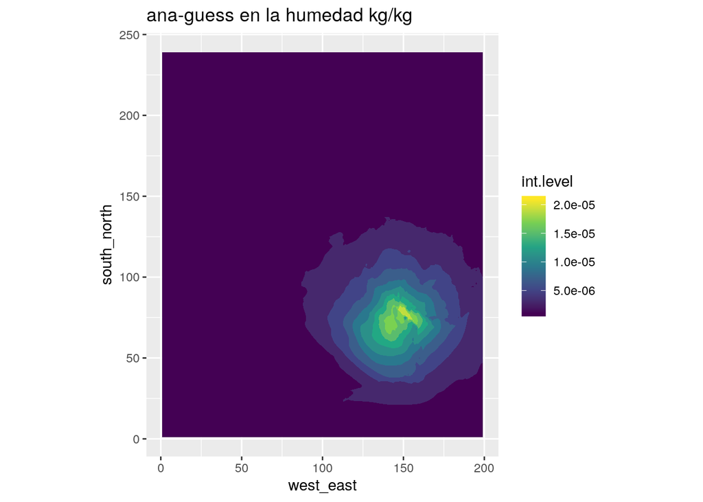

```r
model[bottom_top == 1] %>%
  dcast(bottom_top + south_north + west_east ~ model, value.var = "QVAPOR") %>%
  ggplot(aes(west_east, south_north)) +
  geom_contour_fill(aes(z = (ana187_q - guess))) +
  scale_fill_viridis_c() +
  coord_fixed() +
  labs(title = "ana-guess en la humedad kg/kg")
```